# Forecasting Equity Market Trends and Volatility using Meta’s Prophet Model

A Case Study of ES Futures and the VIX Index

Abduljelil Abdulalim

Originally published March 2026 · Out-of-sample validation added August 2026

# Introduction

Financial markets generate large amounts of time-series data that analysts use to study trends, risk, and market behaviour. In this project I look to analyse two widely followed financial indicators: the E-mini S&P 500 Futures (ES) and the CBOE Volatility Index (VIX). ES futures are commonly used as a proxy for the overall U.S. equity market, while the VIX measures the market’s expectation of future volatility. These two series are often analysed together because equity prices and market volatility are closely related.

## Background on Financial Markets

Equity markets are influenced by a combination of economic conditions, investor sentiment, and global events. As a result, financial time series often display trends, periods of volatility, and sudden market shocks. The E-mini S&P 500 Futures contract is widely used by traders and institutions to gain exposure to the U.S. stock market, as it closely tracks the performance of the S&P 500 Index. Due to its high liquidity and continuous trading, ES futures are commonly analysed when studying market behaviour.

## Market Volatility

Alongside price movements, volatility is an important aspect of financial markets. The CBOE Volatility Index (VIX) represents the market’s expectation of volatility over the next 30 days based on options prices. The VIX tends to increase during periods of market uncertainty or financial stress, when investors are generally expecting larger price movements. For example, volatility increased sharply during events such as the COVID-19 Market Crash and the 2008 Financial Crisis. Because of this behaviour, the VIX is often used as a measure of market risk, and it has earned the nickname “the fear index”.

## Project Objective

Studying equity markets alongside volatility can reveal important insights into market behaviour. Falling equity prices are often accompanied by rising volatility, while stable markets tend to coincide with lower volatility. A clear example occurred during the COVID-19 Market Crash in 2020, when the CBOE Volatility Index surged to around 82 while the S&P 500 Index fell by roughly 34%. This event highlights the strong link between market prices and expected volatility, which is why both indicators are closely monitored by traders and risk managers.

In this project, historical data from E-mini S&P 500 Futures and the VIX are analysed using the forecasting framework developed by Meta called Prophet, to examine whether these patterns can help produce short-term forecasts of both market prices and volatility. The resulting models are then validated out-of-sample against a naive random walk and an ARIMA benchmark, to test whether the forecasts carry genuine information or merely fit the historical data well.

# Data

## Data Collection and Cleaning

Historical daily data for the E-mini S&P 500 futures (ES) and the CBOE Volatility Index (VIX) were obtained from Yahoo Finance using the `quantmod` package in R, covering 2 January 2007 to 1 August 2026. These datasets are provided in xts format, which is well suited for time-series analysis.

Both the start and end dates are fixed explicitly rather than left to default. Without a fixed end date the dataset would extend to whatever the current date happened to be, and the results reported below would change every time the document was recompiled.

Before modelling, the data was cleaned to ensure reliability and consistency. Any missing observations were removed using the `na.omit()` function. This step is important as missing values can distort model estimation and lead to inaccurate forecasts.

The cleaned time series were then transformed into data frames compatible with the Prophet model. Specifically, each dataset was reformatted into two columns: `ds`, representing the date index, and `y`, representing the observed value (closing price). This structure is required by the Prophet framework for time-series forecasting.

```r
library(quantmod)
library(prophet)

DATA_FROM <- "2007-01-01"
DATA_TO   <- "2026-08-01"   # fixed end date so results are reproducible

getSymbols("ES=F", src = "yahoo", from = DATA_FROM, to = DATA_TO)
```

```
## [1] "ES=F"
```

```r
getSymbols("^VIX", src = "yahoo", from = DATA_FROM, to = DATA_TO)
```

```
## [1] "VIX"
```

```r
es_clean  <- na.omit(`ES=F`)
vix_clean <- na.omit(VIX)
```

```r
es_data <- data.frame(
  ds = index(es_clean),
  y  = as.numeric(Cl(es_clean))
)

vix_data <- data.frame(
  ds = index(vix_clean),
  y  = as.numeric(Cl(vix_clean))
)
```

After cleaning, this leaves 4926 trading days for ES and 4926 for the VIX.

## Exploratory Data Analysis

To understand the behaviour of the datasets, the historical time series for both ES futures and the VIX were visualised.

The ES series shows a clear long-term upward trend, reflecting overall growth in the equity market. However, there are noticeable declines during periods of financial stress, such as the 2020 COVID-19 crash.

In contrast, the VIX exhibits a very different pattern. Rather than following a smooth trend, it remains relatively low during stable periods but spikes sharply during times of uncertainty.

This inverse relationship is important: when ES prices fall, the VIX tends to rise. This suggests that volatility increases when markets become unstable.

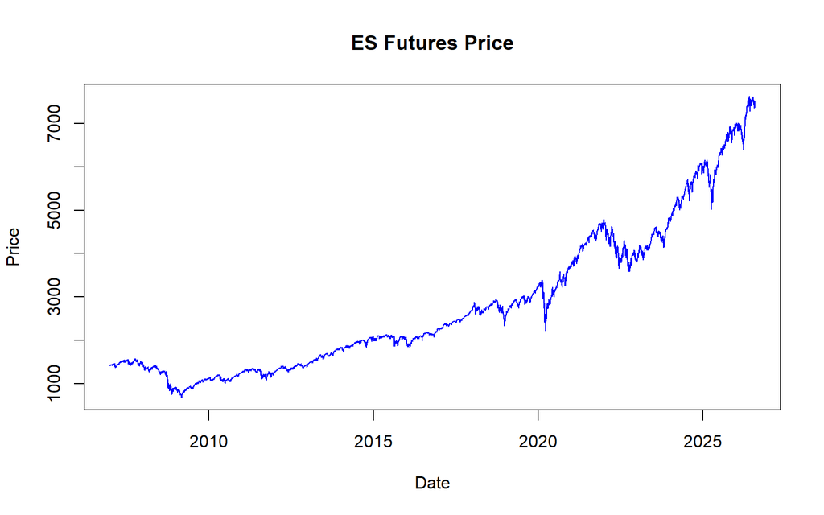

```r
plot(index(es_clean), Cl(es_clean),
     type = "l", col = "blue",
     main = "ES Futures Price",
     xlab = "Date", ylab = "Price")
```

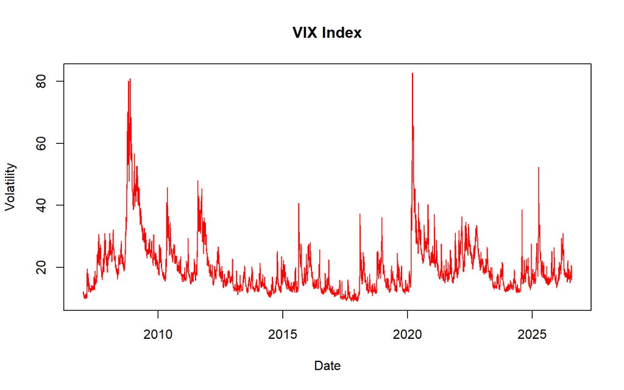

```r
plot(index(vix_clean), Cl(vix_clean),
     type = "l", col = "red",
     main = "VIX Index",
     xlab = "Date", ylab = "Volatility")
```

# Modelling

## Prophet Model — ES Forecast

```r
es_model <- prophet(es_data)
```

```r
es_future <- make_future_dataframe(es_model, periods = 30)
```

```r
es_forecast <- predict(es_model, es_future)
```

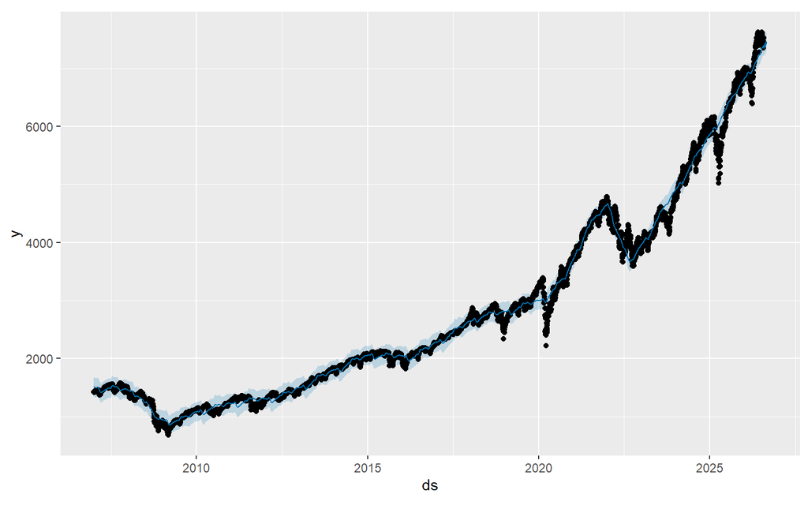

```r
plot(es_model, es_forecast)
```

## Prophet Model — VIX Forecast

```r
vix_model   <- prophet(vix_data)
```

```
## Disabling daily seasonality. Run prophet with daily.seasonality=TRUE to override this.
```

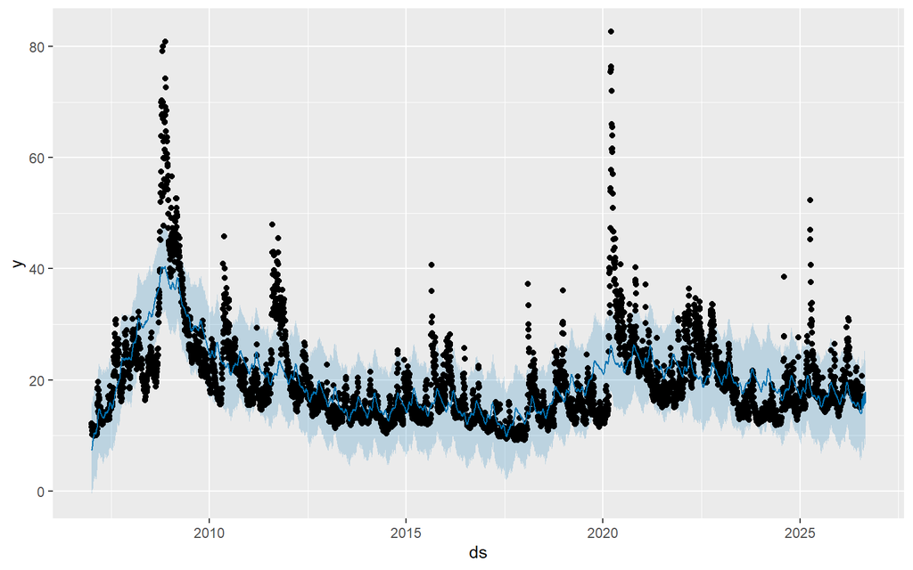

```r
vix_future  <- make_future_dataframe(vix_model, periods = 30)
vix_forecast <- predict(vix_model, vix_future)
plot(vix_model, vix_forecast)
```

## Interpreting the VIX Forecast

Having applied Prophet to the ES series, the same framework was fitted to the VIX. Prophet decomposes the series into trend and seasonal components, and a future dataframe extending 30 days ahead was created from the historical VIX data.

Unlike ES prices, the VIX does not follow a smooth long-term trend but instead exhibits sudden spikes during periods of market stress. The forecast reflects this: relatively stable periods with the potential for sharp increases in volatility, which highlights the reactive nature of the VIX as a measure of market uncertainty.

One limitation apparent from the outset is that the VIX can spike very suddenly, which makes it difficult for a model like Prophet to capture extreme market events. Whether the model performs adequately in more ordinary conditions is a separate question, and one that the in-sample plots above cannot answer. It is addressed in the validation section later in this document.

## Comparison of ES and VIX

The comparison between ES futures and the VIX shows a strong inverse relationship between equity market performance and volatility. Measured on daily log returns, the correlation between the two series is −0.74. While the ES series generally follows a long-term upward trend, the VIX tends to remain low during stable periods and spike sharply during market downturns.

This relationship is particularly evident during periods of financial stress. For example, during the 2020 COVID-19 market crash, ES prices declined significantly while the VIX surged to extreme levels. This shows that when equity prices fall, volatility tends to rise, reflecting increased uncertainty and risk in the market.

From the in-sample forecasting output, the ES model captures gradual trends in market prices, whereas the VIX model reflects the irregular and reactive nature of volatility. Together, these models appear to provide complementary insights: ES indicates market direction, while the VIX reflects the level of risk and uncertainty. From a trading perspective, this relationship is useful, as rising volatility often signals increased uncertainty and potential risk. Understanding it is valuable for traders and analysts, as combining both indicators can provide a more complete view of market conditions.

## Combined Analysis of ES and VIX

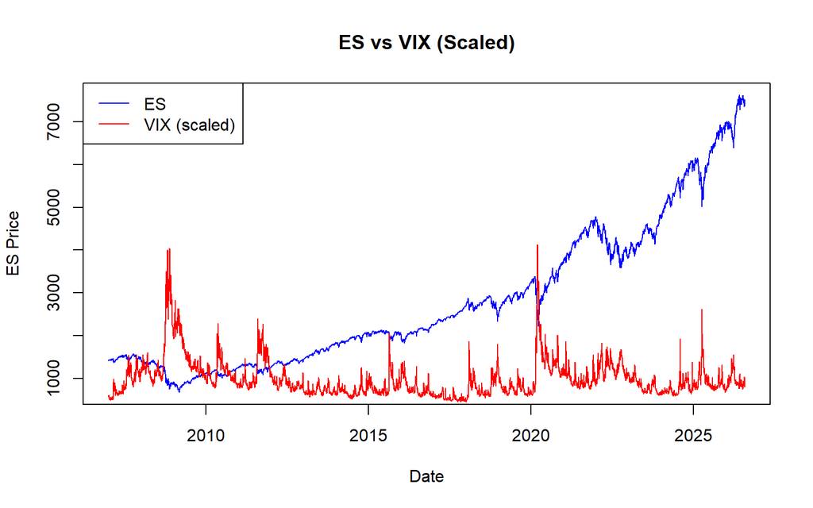

```r
plot(index(es_clean), Cl(es_clean), type = "l",
     col = "blue", xlab = "Date", ylab = "ES Price",
     main = "ES vs VIX (Scaled)")

lines(index(vix_clean), Cl(vix_clean) * 50, col = "red")

legend("topleft",
       legend = c("ES", "VIX (scaled)"),
       col = c("blue", "red"),
       lty = 1)
```

```r
common  <- merge(Cl(es_clean), Cl(vix_clean), join = "inner")
es_ret  <- diff(log(common[,1]))[-1]
vix_ret <- diff(log(common[,2]))[-1]
round(as.numeric(cor(es_ret, vix_ret)), 3)
```

```
## [1] -0.735
```

To further examine the relationship between equity prices and market volatility, the ES and VIX series were plotted together on the same chart. As the VIX operates on a much smaller scale than ES prices, it was rescaled to allow for meaningful visual comparison.

The correlation above is computed on daily log returns rather than on price levels. Correlating the levels of two trending series produces inflated and largely spurious values, because both series share a common time trend. Differencing to returns removes that trend and gives a figure that reflects the co-movement of the two series rather than their shared drift.

The combined plot illustrates the inverse relationship quantified above. Periods where ES prices decline are often accompanied by noticeable increases in the VIX, and this is particularly evident during major market events. The visual scaling factor of 50 is arbitrary and chosen only for legibility, which is precisely why the correlation figure is the more reliable statement of the relationship.

# Out-of-Sample Validation

The forecasts above were produced by fitting each model to the full history and projecting forward. This is standard for exploratory work, but it does not answer the question that matters: would these forecasts have been any good?

A model always looks convincing on the data it was fitted to. Prophet’s in-sample fit tells us it can describe the past, not that it can forecast the future. To test that properly, I ran a rolling-origin cross-validation against two benchmarks.

## Method

1. Train on all data up to a cutoff date.
2. Forecast the next 30 trading days.
3. Score the forecast against what actually happened.
4. Move the cutoff forward 90 trading days and repeat.

This produces a series of out-of-sample tests rather than a single result that could be luck. Every model sees identical folds, so the comparison is like-for-like.

**Benchmarks:**

- **Naive (random walk)** — the forecast is simply the last observed value. If a model cannot beat this, it is not adding information.
- **ARIMA** — order selected by `auto.arima()` on log values.

**Metrics:** RMSE, MAE, and directional accuracy — the proportion of days in the test window where the model correctly predicted whether the price would be above or below the last observed training value, where 0.5 is a coin flip. Directional accuracy is included because RMSE alone can hide a model that is close on average but consistently wrong about direction.

```r
library(forecast)
library(zoo)
library(dplyr)
library(ggplot2)
library(tidyr)

HORIZON <- 30    # trading days
INITIAL <- 1500  # trading days in first training window
STEP    <- 90    # trading days advanced per fold

rmse <- function(a, f) sqrt(mean((a - f)^2))
mae  <- function(a, f) mean(abs(a - f))
dir_acc <- function(a, f, last_train) {
  mean(sign(a - last_train) == sign(f - last_train))
}
```

```r
prophet_forecast <- function(train, test, last_train, ...) {
  m   <- suppressMessages(prophet(train, ...))
  fut <- make_future_dataframe(m, periods = ceiling(HORIZON * 1.6), freq = "day")
  fc  <- suppressMessages(predict(m, fut))
  fc$ds <- as.Date(fc$ds)
  v <- fc$yhat[match(as.Date(test$ds), fc$ds)]
  if (any(is.na(v))) {
    v <- zoo::na.locf(v, na.rm = FALSE)
    v[is.na(v)] <- last_train
  }
  as.numeric(v)
}

run_validation <- function(data, label) {
  cutoffs <- seq(from = INITIAL, to = nrow(data) - HORIZON, by = STEP)
  out <- vector("list", length(cutoffs))

  for (i in seq_along(cutoffs)) {
    cut        <- cutoffs[i]
    train      <- data[1:cut, ]
    test       <- data[(cut + 1):(cut + HORIZON), ]
    last_train <- tail(train$y, 1)

    f_naive <- rep(last_train, HORIZON)

    arima_ok <- TRUE
    f_arima <- tryCatch({
      fit <- auto.arima(log(train$y), seasonal = FALSE, stepwise = TRUE)
      as.numeric(exp(forecast(fit, h = HORIZON)$mean))
    }, error = function(e) { arima_ok <<- FALSE; f_naive })

    prophet_ok <- TRUE
    f_prophet <- tryCatch(
      prophet_forecast(train, test, last_train),
      error = function(e) { prophet_ok <<- FALSE; f_naive })

    out[[i]] <- data.frame(
      fold = i, cutoff = train$ds[cut],
      naive_rmse   = rmse(test$y, f_naive),
      naive_mae    = mae(test$y, f_naive),
      arima_rmse   = rmse(test$y, f_arima),
      arima_mae    = mae(test$y, f_arima),
      prophet_rmse = rmse(test$y, f_prophet),
      prophet_mae  = mae(test$y, f_prophet),
      arima_dir    = dir_acc(test$y, f_arima,   last_train),
      prophet_dir  = dir_acc(test$y, f_prophet, last_train),
      arima_ok = arima_ok, prophet_ok = prophet_ok
    )
  }
  bind_rows(out)
}
```

```r
es_cv  <- run_validation(es_data,  "ES")
vix_cv <- run_validation(vix_data, "VIX")
```

A silent fallback to the naive forecast would bias the comparison in favour of the other models, so failures are counted explicitly rather than assumed absent.

```r
cat("ES  — ARIMA failures:", sum(!es_cv$arima_ok),
    "| Prophet failures:", sum(!es_cv$prophet_ok), "\n")
```

```
## ES  — ARIMA failures: 0 | Prophet failures: 0
```

```r
cat("VIX — ARIMA failures:", sum(!vix_cv$arima_ok),
    "| Prophet failures:", sum(!vix_cv$prophet_ok), "\n")
```

```
## VIX — ARIMA failures: 0 | Prophet failures: 0
```

```r
summarise_cv <- function(cv) {
  tab <- data.frame(
    Model = c("Naive (random walk)", "ARIMA (auto)", "Prophet"),
    RMSE  = c(mean(cv$naive_rmse), mean(cv$arima_rmse), mean(cv$prophet_rmse)),
    MAE   = c(mean(cv$naive_mae),  mean(cv$arima_mae),  mean(cv$prophet_mae))
  )
  tab$`RMSE vs naive` <- round(tab$RMSE / tab$RMSE[1], 3)
  tab
}

es_tab  <- summarise_cv(es_cv)
vix_tab <- summarise_cv(vix_cv)
```

## Results

ES Futures — 38 folds, 30-trading-day horizon

| Model | RMSE | MAE | RMSE vs naive |
| --- | --- | --- | --- |
| Naive (random walk) | 135.582 | 115.817 | 1.000 |
| ARIMA (auto) | 134.639 | 115.699 | 0.993 |
| Prophet | 261.960 | 249.937 | 1.932 |

VIX — 38 folds, 30-trading-day horizon

| Model | RMSE | MAE | RMSE vs naive |
| --- | --- | --- | --- |
| Naive (random walk) | 4.097 | 3.415 | 1.000 |
| ARIMA (auto) | 3.976 | 3.294 | 0.971 |
| Prophet | 5.120 | 4.495 | 1.250 |

```r
report <- function(cv, label) {
  cat("=====", label, "=====\n")
  cat("Folds where naive had lower RMSE:\n")
  cat("  vs Prophet:", sum(cv$naive_rmse < cv$prophet_rmse), "of", nrow(cv), "\n")
  cat("  vs ARIMA:  ", sum(cv$naive_rmse < cv$arima_rmse),   "of", nrow(cv), "\n")
  cat("Directional accuracy (0.5 = coin flip):\n")
  cat("  ARIMA:  ", round(mean(cv$arima_dir), 3), "\n")
  cat("  Prophet:", round(mean(cv$prophet_dir), 3), "\n")
  tt <- t.test(cv$prophet_rmse, cv$naive_rmse, paired = TRUE)
  cat("Paired t-test (Prophet vs naive RMSE): p =",
      format.pval(tt$p.value, digits = 3), "\n\n")
}
report(es_cv,  "ES FUTURES")
```

```
## ===== ES FUTURES =====
## Folds where naive had lower RMSE:
##   vs Prophet: 28 of 38
##   vs ARIMA:   21 of 38
## Directional accuracy (0.5 = coin flip):
##   ARIMA:   0.502
##   Prophet: 0.48
## Paired t-test (Prophet vs naive RMSE): p = 0.000373
```

```r
report(vix_cv, "VIX")
```

```
## ===== VIX =====
## Folds where naive had lower RMSE:
##   vs Prophet: 25 of 38
##   vs ARIMA:   21 of 38
## Directional accuracy (0.5 = coin flip):
##   ARIMA:   0.505
##   Prophet: 0.552
## Paired t-test (Prophet vs naive RMSE): p = 0.0104
```

Averages alone can conceal how consistent a result is, so the significance tests below check whether the differences reported above hold up, and whether the one above-chance directional result is distinguishable from noise.

```r
# Prophet's directional accuracy on VIX was 0.552 — is that better than chance?
t.test(vix_cv$prophet_dir, mu = 0.5)
```

```
##
##  One Sample t-test
##
## data:  vix_cv$prophet_dir
## t = 1.138, df = 37, p-value = 0.2625
## alternative hypothesis: true mean is not equal to 0.5
## 95 percent confidence interval:
##  0.4596031 0.6439057
## sample estimates:
## mean of x
## 0.5517544
```

```r
# ARIMA had marginally lower mean RMSE than naive. Is the difference real?
t.test(es_cv$arima_rmse,  es_cv$naive_rmse,  paired = TRUE)
```

```
##
##  Paired t-test
##
## data:  es_cv$arima_rmse and es_cv$naive_rmse
## t = -0.37414, df = 37, p-value = 0.7104
## alternative hypothesis: true mean difference is not equal to 0
## 95 percent confidence interval:
##  -6.051731  4.165182
## sample estimates:
## mean difference
##      -0.9432744
```

```r
t.test(vix_cv$arima_rmse, vix_cv$naive_rmse, paired = TRUE)
```

```
##
##  Paired t-test
##
## data:  vix_cv$arima_rmse and vix_cv$naive_rmse
## t = -0.94426, df = 37, p-value = 0.3512
## alternative hypothesis: true mean difference is not equal to 0
## 95 percent confidence interval:
##  -0.3795999  0.1382616
## sample estimates:
## mean difference
##      -0.1206692
```

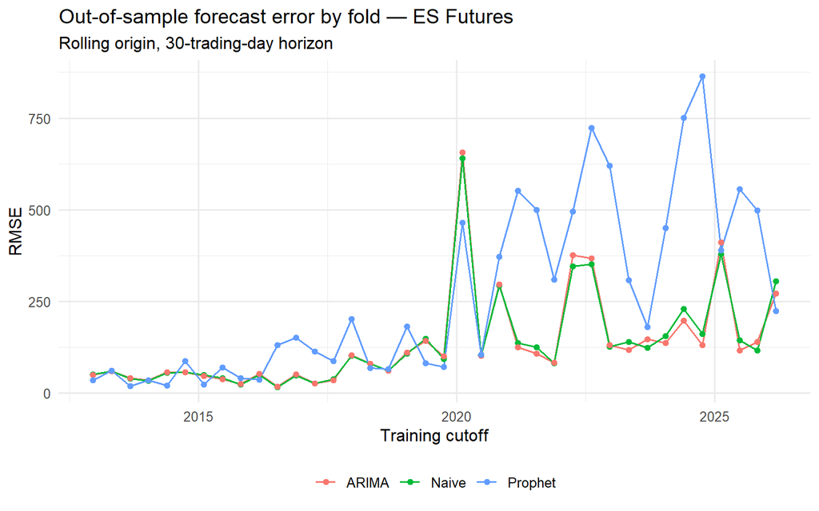

```r
plot_folds <- function(cv, label) {
  cv %>%
    select(cutoff, naive_rmse, arima_rmse, prophet_rmse) %>%
    pivot_longer(-cutoff, names_to = "model", values_to = "rmse") %>%
    mutate(model = recode(model, naive_rmse = "Naive",
                          arima_rmse = "ARIMA", prophet_rmse = "Prophet")) %>%
    ggplot(aes(cutoff, rmse, colour = model)) +
    geom_line(linewidth = 0.7) + geom_point(size = 1.6) +
    labs(title = paste0("Out-of-sample forecast error by fold — ", label),
         subtitle = paste0("Rolling origin, ", HORIZON, "-trading-day horizon"),
         x = "Training cutoff", y = "RMSE", colour = NULL) +
    theme_minimal(base_size = 12) + theme(legend.position = "bottom")
}
plot_folds(es_cv,  "ES Futures")
```

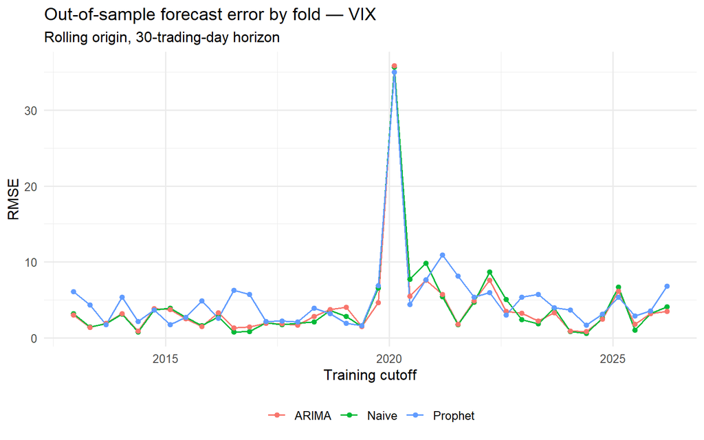

```r
plot_folds(vix_cv, "VIX")
```

## Interpretation

**Prophet did not beat the random walk on either series.** It was roughly twice as inaccurate as the naive forecast on ES and 25% worse on the VIX, and in both cases the difference is statistically significant rather than the product of a few unlucky folds.

This is the expected result for equity prices, and it is worth stating plainly rather than presenting only the more flattering in-sample charts shown earlier. Daily index prices behave close to a random walk: the best available estimate of the price in thirty days is the price today. Prophet is designed for business time series with genuine repeating structure — weekly retail cycles, annual demand patterns — and equity prices do not contain that structure.

The specific failure mechanism is Prophet’s trend component. Prophet fits a piecewise-linear trend with changepoints and extrapolates the most recent segment forward. On a random walk the recent trend carries no information about the future, so projecting it forward moves the forecast away from the last observed price and accumulates error as the horizon extends. Holding the last value flat — the naive forecast — is a strictly better default.

One caveat applies to reading these charts. RMSE is measured in index points, and ES rose from roughly 2,000 to over 6,000 across the sample, so the error of every model grows in absolute terms as the price level rises. The relevant comparison is therefore between models within each fold rather than across time. Reporting percentage errors would separate the two effects and is a natural robustness check.

**ARIMA converged on the naive forecast.** At 0.993 and 0.971 relative RMSE the two are effectively indistinguishable. This is what `auto.arima()` should do here: after differencing, little systematic structure remains, so the selected model sits close to a random walk with drift and reproduces the benchmark.

The apparent 0.7% and 2.9% improvements are not real. Paired t-tests give p = 0.71 for ES and p = 0.35 for the VIX, with confidence intervals spanning zero in both cases, so ARIMA’s mean advantage is indistinguishable from noise. The fold counts point the same way: naive had the lower error in 21 of 38 folds on both series, meaning ARIMA loses more often than it wins despite the marginally better average. Reporting only the mean would have suggested a small edge that the test shows is not there.

**Directional accuracy was close to chance in almost every case.** ARIMA sat at 0.502 on ES and 0.505 on the VIX, and Prophet at 0.480 on ES — indistinguishable from a coin flip, and in Prophet’s case marginally worse than one. The highest figure is Prophet on the VIX at 0.552, which is the only result above chance in nominal terms.

A one-sample t-test against 0.5 gives p = 0.26, with a 95% confidence interval of [0.460, 0.644]. That interval spans everything from slightly worse than chance to substantially better, so across 38 folds this result is not distinguishable from a coin flip and should not be read as evidence of forecasting skill. Volatility does mean-revert, which gives a level-and-trend model more to work with than it has for prices, and a larger sample might separate the two. On this evidence it does not.

Reporting both metrics is still worthwhile, even though neither produced a positive result. A model can be poorly calibrated in magnitude while carrying information about direction, and the two would not necessarily move together. Testing the one figure that looked promising, rather than reporting it at face value, is what turns a 0.552 into a defensible statement about what the data can and cannot support.

## Does the Default Seasonality Help?

The models above use Prophet’s defaults. For daily data spanning several years, Prophet automatically enables yearly and weekly seasonality. Equity prices have no meaningful annual cycle, and with weekends absent from the data a weekly component largely fits day-of-week noise. Whether these components help or hurt is testable rather than assumable.

```r
seasonality_test <- function(data, label) {
  cutoffs <- seq(from = INITIAL, to = nrow(data) - HORIZON, by = STEP)
  on <- c(); off <- c()
  for (cut in cutoffs) {
    train <- data[1:cut, ]
    test  <- data[(cut + 1):(cut + HORIZON), ]
    lt    <- tail(train$y, 1)
    on  <- c(on,  rmse(test$y, prophet_forecast(train, test, lt,
                 yearly.seasonality = TRUE,  weekly.seasonality = TRUE,
                 daily.seasonality = FALSE)))
    off <- c(off, rmse(test$y, prophet_forecast(train, test, lt,
                 yearly.seasonality = FALSE, weekly.seasonality = FALSE,
                 daily.seasonality = FALSE)))
  }
  cat(label, "— seasonality ON:", round(mean(on), 2),
      "| OFF:", round(mean(off), 2),
      "| change:", paste0(round((mean(off)/mean(on) - 1) * 100, 1), "%"), "\n")
  invisible(data.frame(on = mean(on), off = mean(off)))
}

es_seas  <- seasonality_test(es_data,  "ES ")
```

```
## ES  — seasonality ON: 261.96 | OFF: 258.75 | change: -1.2%
```

```r
vix_seas <- seasonality_test(vix_data, "VIX")
```

```
## VIX — seasonality ON: 5.12 | OFF: 4.92 | change: -3.9%
```

Effect of disabling yearly and weekly seasonality on out-of-sample RMSE

| Series | Seasonality ON | Seasonality OFF | Change |
| --- | --- | --- | --- |
| ES | 261.96 | 258.75 | -1.2% |
| VIX | 5.12 | 4.92 | -3.9% |

As a check on consistency, the “seasonality ON” figures reproduce the Prophet results from the main validation above — 261.96 against 262.0 for ES, and 5.12 for the VIX. This is expected, since Prophet’s default settings are exactly the configuration being re-run, and it confirms the two procedures agree.

Disabling yearly and weekly seasonality improved forecast accuracy on both series, which supports the concern that these components were fitting noise rather than structure. The effect is larger on the VIX than on ES.

The size of the improvement is the more important point, however. With seasonality disabled, Prophet’s ES error falls from 262.0 to 258.75 — still 1.9 times the naive benchmark of 135.6. **The default settings were not the reason Prophet underperformed.** Removing an inappropriate seasonal component gives a marginal gain; it does not address the trend extrapolation that drives the bulk of the error. It would have been easy to present the seasonality result as the explanation and stop there, and it would have been wrong.

## Limitations

- The 30-trading-day horizon is a single choice. Relative performance may differ at shorter horizons, where the naive forecast is harder still to beat, or at longer ones.
- Prophet was run close to its defaults. Tuning `changepoint.prior.scale` to make the trend less flexible would likely narrow the gap, though the mechanism described above suggests it would not close it.
- Folds advance 90 trading days with 30-day test windows, so test periods do not overlap, but training windows are nested and expanding. Fold results are therefore not fully independent, and the significance tests should be read with that in mind.
- Only point forecasts were assessed. Prophet produces uncertainty intervals, and evaluating their calibration would be a separate and worthwhile exercise.

# Conclusion

This project examined the relationship between equity market performance and volatility using ES futures and the VIX, and tested whether Prophet could produce useful forecasts of either.

The inverse relationship between the two series is clear and quantifiable: the correlation of daily log returns is −0.74, and the pattern is visible across the 2008 financial crisis, the 2020 COVID-19 crash and the 2022 bear market. This is a descriptive finding and it holds.

The forecasting result is negative, and it is the more useful of the two. Across 38 out-of-sample folds, Prophet failed to beat a naive random walk on either series — by a factor of 1.9 on ES and 1.25 on the VIX, with both differences statistically significant. ARIMA converged on the naive forecast rather than improving upon it. Directional accuracy was indistinguishable from a coin flip in every case, including the one figure that initially appeared to beat it. The claim that Prophet “captures long-term trend effectively” describes its in-sample fit, not its forecasting ability, and the two are not the same thing.

The wider point is methodological. The in-sample forecast charts presented earlier in this document look entirely reasonable, and without out-of-sample testing there would have been no way to know they were misleading. The single most informative step in this project was benchmarking against a model so simple it has no parameters at all. A forecasting model that cannot beat “tomorrow equals today” is not adding information, however plausible its output appears.

Whether combining the two series — using volatility as an input to price forecasting, or vice versa — would improve predictive performance is not tested here, and remains the natural next step.

# References

- Taylor, S.J. and Letham, B. (2018). *Forecasting at Scale*. The American Statistician. (Prophet model)
- Yahoo Finance. Available at: https://finance.yahoo.com/  
  (Data source for ES futures and VIX)
- Quantmod Package Documentation. Available at: https://cran.r-project.org/package=quantmod
- Prophet Package Documentation. Available at: https://facebook.github.io/prophet/
- Chicago Board Options Exchange (CBOE). Available at: https://www.cboe.com/  
  (Information on the VIX Index)